# Where are the Women?

Stephanie Rudolph

11/7/2025

# Women and Hollywood

Sexism against women has long been present in the film industry of Western cultures. Both in front of and behind the camera, and in the ways that the stories of women are told, time and time again, Hollywood under or misrepresents them. In order to measure gap in representation, we will be using data that indicates whether or not movies pass the Bechdel Test.

# What is the Bechdel Test?

The Bechdel Test is a test that measures gender inclusivity of films with three simple rules to pass: 1. A film must have 2 women in it. 2. Those two women must talk to each other. 3. The subject of their conversation must be something other than a man. Though extremely simple, a surprising number of films do not pass this test, despite making up roughly half of the human population. This indicates a gap in the film industry of adequate representation of women.

# The Dataset

For this Project, I will be using the Bechdel Dataset from the library FiveThirtyEight. This data comes from the FiveThirtyEight article “The Dollar-And-Cents Case Against Hollywood’s Exclusion of Women”. In this data, we will explore films that pass vs fail the Bechdel Test and what that means for Hollywood.

This set includes data about films and their titles, year of release, imdb url, bechdel test reuslts, budget, domestic gross income, international gross income, (raw and adjusted to 2013 inflation), bechdel code, period code, and decade code.

```r
# Load necessary R Packages
library(tidyverse)
library(fivethirtyeight)
```

## Wrangling Our Data

### Overview

The first thing we will do with this data is wrangle it so it will be ready for our analysis. After saving the Bechdel data to a variable, we will use the ‘%>%’ operator to pipe our data through various functions until it is wrangled appropriately.

### Getting Started

In order to know where to start, lets first take a look at what the raw dataset looks like. To get a feel for our data, we will use the sample_n function from the dyplr library to get 10 random rows and see what the raw data really looks like.

```r
#save ther bechdel data from fivethirtyeight to a variable, and view it
bechdeldata <- bechdel
sample_n(bechdeldata, 10)
```

```
## # A tibble: 10 × 15
##     year imdb      title  test  clean_test binary budget domgross intgross code
##    <int> <chr>     <chr>  <chr> <ord>      <chr>   <int>    <dbl>    <dbl> <chr>
##  1  2010 tt0968264 The C… dubi… dubious    FAIL   2.5 e7 11538204   1.59e7 2010…
##  2  2005 tt0398712 Assau… ok    ok         PASS   3   e7 20040895   3.60e7 2005…
##  3  2005 tt0401792 Sin C… ok-d… ok         PASS   4   e7 74103820   1.59e8 2005…
##  4  2010 tt1194417 Casin… nota… notalk     FAIL   1.25e7  2039869   2.08e6 2010…
##  5  2009 tt1179891 My Bl… men   men        FAIL   1.4 e7 51545952   1.03e8 2009…
##  6  2005 tt0402399 The N… dubi… dubious    FAIL   3   e7 12712093   2.62e7 2005…
##  7  2005 tt0397101 The S… ok    ok         PASS   4   e7 47907715   9.23e7 2005…
##  8  2009 tt1017460 Splice ok    ok         PASS   3   e7 17010170   2.25e7 2009…
##  9  2005 tt0408790 Fligh… ok    ok         PASS   5.50e7 89706988   2.26e8 2005…
## 10  1996 tt0117603 Set I… ok    ok         PASS   9   e6 36049108   3.60e7 1996…
## # ℹ 5 more variables: budget_2013 <int>, domgross_2013 <dbl>,
## #   intgross_2013 <dbl>, period_code <int>, decade_code <int>
```

### Analysis

Looking at this table, there are a lot of different columns. For this project, we are only interested in the year of the films, whether or not they passed the Bechdel Test, the budget and the Total International Gross Income from 2013 (inflation adjusted dollars). Additionally, notice that the binary column, the column’s class in “character”.

In order to get those columns, we will use the select function. Then, to make analysis easier, we will change it be a True/False boolean, using mutate and the case_when function.

Finally, we will group by the binary and year columns, summarize the count of each row, as well as the mean budget, and international gross income, and arrange it in order of the year the films were released to produce a clean table.

```r
#select the columns of interest, mutate the binary column to store pass/fail as a boolean, rather than a string
#then, group by binary and year, to output a table showing the count of True and False results for each year
bechdel_pass<- bechdeldata %>%
  select(year, binary, budget, intgross_2013) %>%
  mutate(binary = case_when(
    binary == "PASS" ~ TRUE,
    binary == "FAIL" ~ FALSE)) %>%
  group_by(binary, year) %>%
  summarize(count=n(), budget=mean(budget), mean_international = mean(intgross_2013, na.rm=T)) %>%
  arrange(year)
```

## Graphics

### Number of Films That Pass Vs Fail The Bechdel Test

For our first graphic, lets see how the number of films that pass vs fail the Bechdel test change over the decades. To do this we will use boxplots (from ggplot) to see how the number of films in these two categories change over the decades.

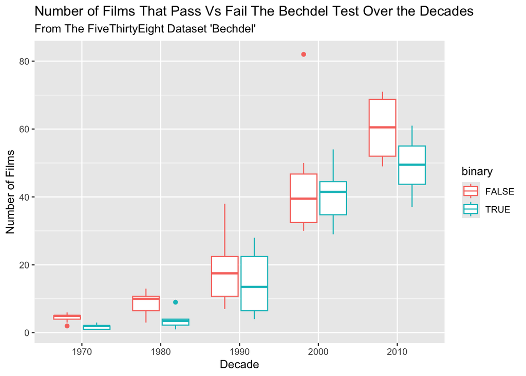

```r
#To create a boxplot, mutate the data to have a decade column, extracted using the year column
#then, use ggplot to output the boxplot
bechdel_result <- bechdel_pass %>%
  mutate(decade = floor(year/10)*10) %>%
ggplot(aes(x=as.factor(decade), y=count, color=binary)) + geom_boxplot() +labs(title="Number of Films That Pass Vs Fail The Bechdel Test Over the Decades", subtitle= "From The FiveThirtyEight Dataset 'Bechdel'", x="Decade", y="Number of Films")
bechdel_result
```

As a reminder, this test is only measuring if there are at least two women who talk to each other about something that is not a man. Even if the number of films that pass vs fail this test is about equal, this still tells us that around half of movies are lacking the bare minimum of representation of women.

Next, lets explore possible biases or incentives that may influence Hollywood to produce films that fail the Bechdel test.

### Comparing Budgets

In order to compare the budgets, we will use a line graph to compare the budgets of films that pass vs fail the Bechdel test.

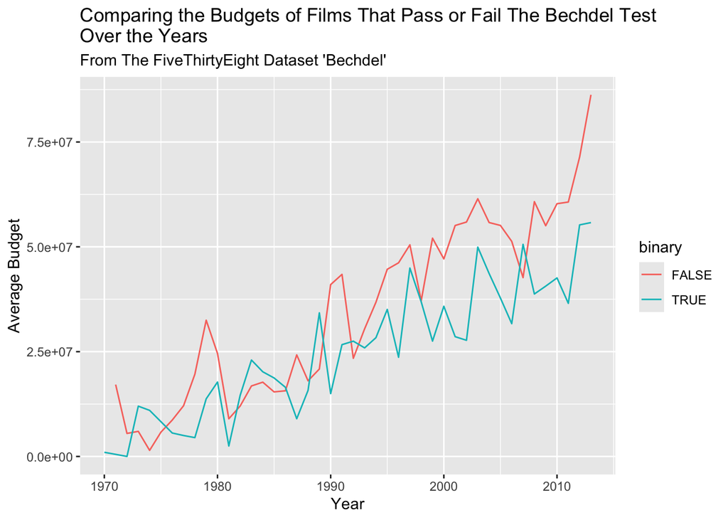

```r
bechdel_budget <- bechdel_pass %>%
  ggplot(aes(x=year, y=budget, color=binary)) + geom_line() +labs(title="Comparing the Budgets of Films That Pass or Fail The Bechdel Test \nOver the Years", subtitle= "From The FiveThirtyEight Dataset 'Bechdel'", x="Year", y="Average Budget")

bechdel_budget
```

This may possibly be explained by the industry viewing films that potray men as more valuable, thus, granting these films higher budgets, or this may be a reflection of the industry viewing female actors themselves less valuable, resulting in lower pay.

If there is a gap in the budgets these films, what is the relationship of the money these films receive between films that pass vs fail?

### Comparing Income

Let’s use a similar graph from the previous section, but replacing the budget axis with the International Gross Income.

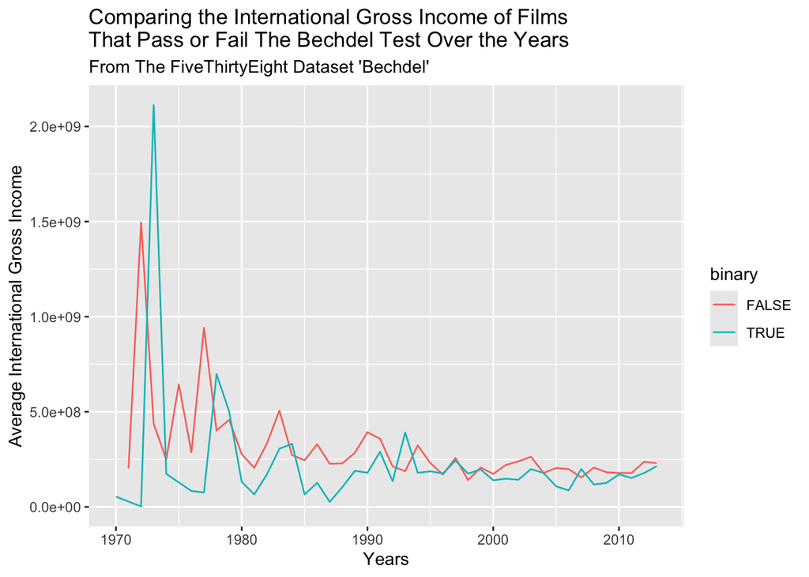

```r
bechdel_budget <- bechdel_pass %>%
  ggplot(aes(x=year, y=mean_international, color=binary)) + geom_line() +labs(title="Comparing the International Gross Income of Films \nThat Pass or Fail The Bechdel Test Over the Years", subtitle= "From The FiveThirtyEight Dataset 'Bechdel'", x="Years", y="Average International Gross Income")

bechdel_budget
```

Even if passing films my have brought in lower incomes internationally, it is important to remember that these films also tended to have smaller budgets. Gaps in income may possibly be explained by the fact that films the pass the Bechdel test recieve less income, which may result in worst quality or ability to advertise or public bias against seeing films that feature women.

# Conclusion

Hollywood produces slightly more films that fail the Bechdel test, than those that pass. Failing films tend to receive higher budgets, and bring in slightly more income than films that do not pass the Bechdel test.

This data alone is not enough to tell us why this gap in representation exists in Hollywood. However, it still informs us that there does exist a lack of female representation in films. This data may help us going forward to increase representation in films. By knowing how many of the films Hollywood is producing fail this test, we can make sure that Hollywood produces more films that pass the Bechdel test, and receive equitable budgeting, which will give them a more fair chance in the industry to earn just as much as less representative films and bias audiences away from less representative films.